# Comparative vaccine effectiveness (ChAdOx1 versus BNT162b2) in Health and Social Care workers

### Time-dependent Cox models

Time-dependent Cox models are used to estimate the time-varying effects for each vaccine type. Two time-scales are used for triangulation:

- On the *calendar time-scale*, time zero is 04 January 2021, and people only contribute follow-up time once they have been vaccinated (i.e., delayed study entry). Vaccine type, time since vaccination in weekly intervals, and the interaction between these two terms are included to estimate time-varying vaccine effects for each vaccine type. In `R`'s `coxph` function, this is modelled using `vaccine_type*week_since_first_dose`
- On the *treatment time-scale*, time zero is the date of vaccination. Date of vaccination is included as an additional baseline covariate using a restricted cubic spline with knots at the first and second tertile, plus boundary knots. Here, follow-up time is stratified into weekly intervals with the vaccine-specific effect estimated within each time-strata. In `R`'s `coxph` function, this is modelled using `vaccine_type:strata(week_since_first_dose)`.

### Pooled Logistic Regression models

We emulate the Cox models described above using pooled logistic regression (PLR), with the outcome risk estimated at daily intervals. This serves two purposes. Firstly, a continuous-time estimate of comparative effectiveness, as opposed to the piecewise-linear approximation above, can be obtained using flexible parametric splines. Secondly, the absolute cumulative risk of each outcome of interest for each vaccine type, marginalised over the population, can be obtained using the parametric g-formula. These models include a restricted cubic spline with 3 degrees of freedom on the timescale of interest, interacted with vaccine type. Cumulative risk is then calculated as the average risk for each day of follow-up predicted by the PLR model, under the (complimentary counterfactual) assumptions that every patient received the BNT162b2 vaccine or that every patient received the ChAdOx1 vaccine.

The person-time dataset needed to fit the PLR model is large and leads to infeasible RAM requirements / computation time. To deal with this, a sampling strategy is used such that all those who experienced an outcome and a random sample of 50000 who did not experience the ouotcome are selected for the models. The models are weighted to recover the characteristics of the complete dataset. This weighting is also applied to the average cumulative risk.

# Results

Note all counts below 6 are redacted and Kaplan-Meier survival estimates are rounded for disclosure control.

## Event rates

[output not shown]

[output cut: 80 more lines]

## Comparative effectiveness

### SARS-CoV-2 positive test

#### Unadjusted

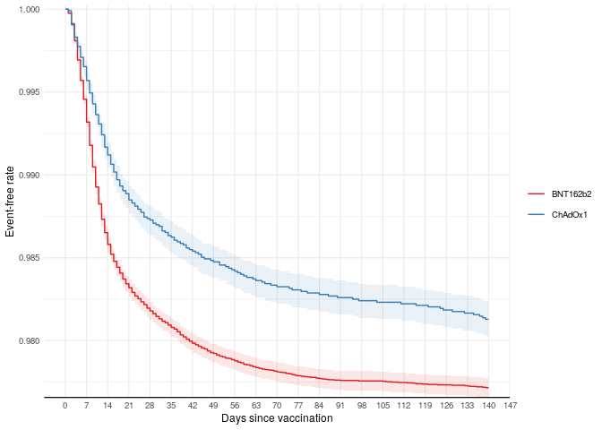

#### Cox

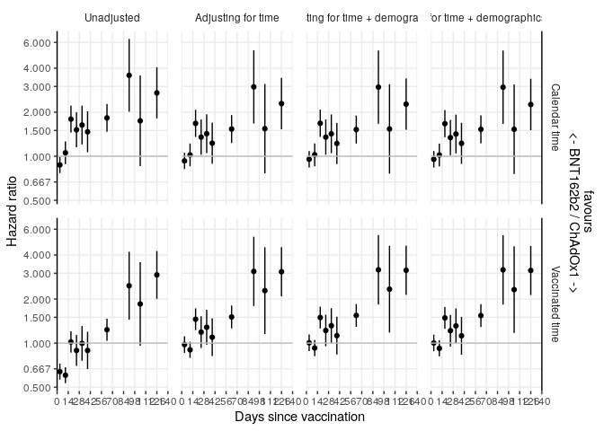

#### PLR, piecewise

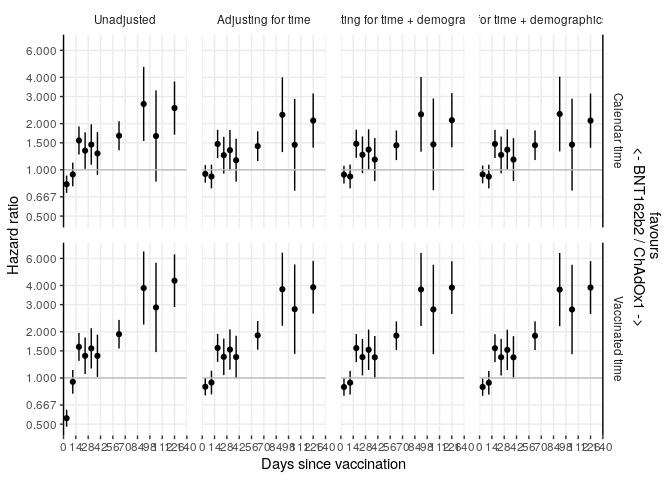

#### PLR, spline

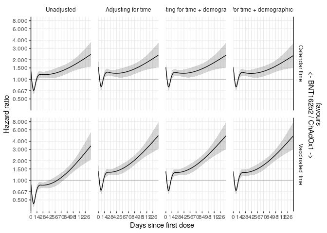

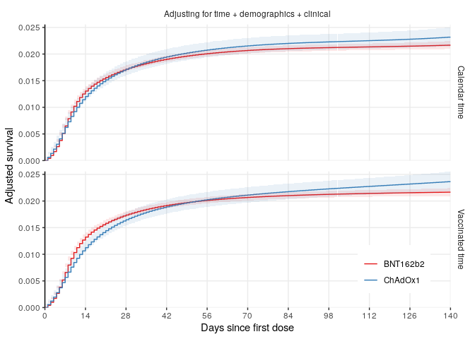

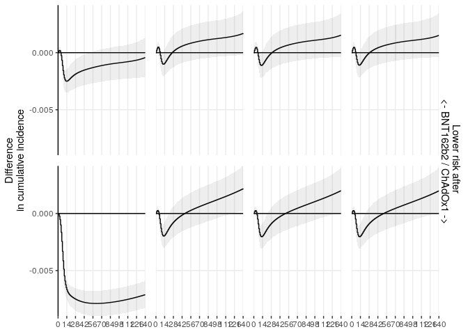

### COVID-19 A&E attendance

#### Unadjusted

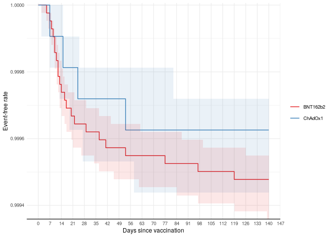

#### Cox

[figure not shown]

#### PLR, piecewise

[figure not shown]

#### PLR, spline

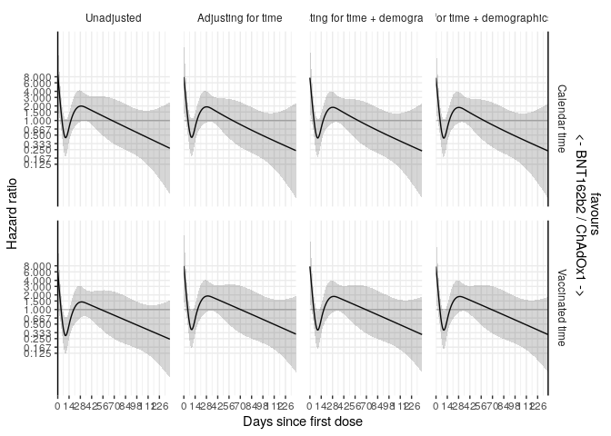

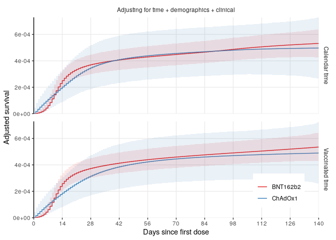

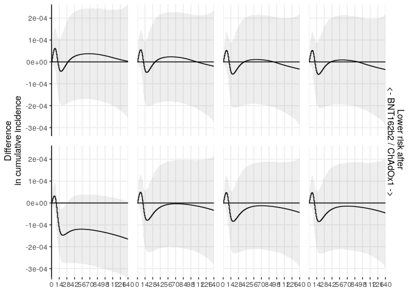

### COVID-19 hospital admission

#### Unadjusted

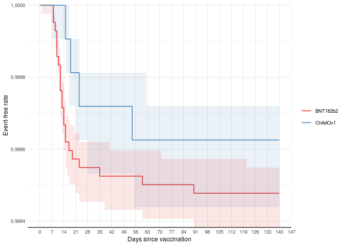

#### Cox

[figure not shown]

#### PLR, piecewise

[figure not shown]

#### PLR, spline

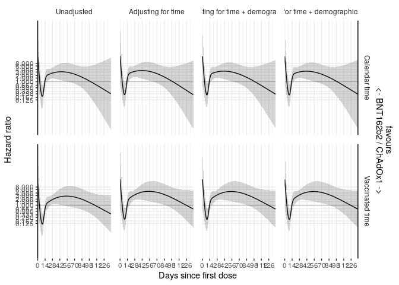

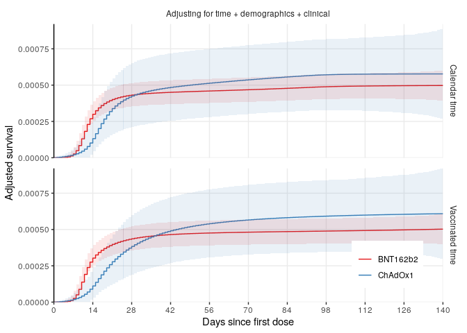

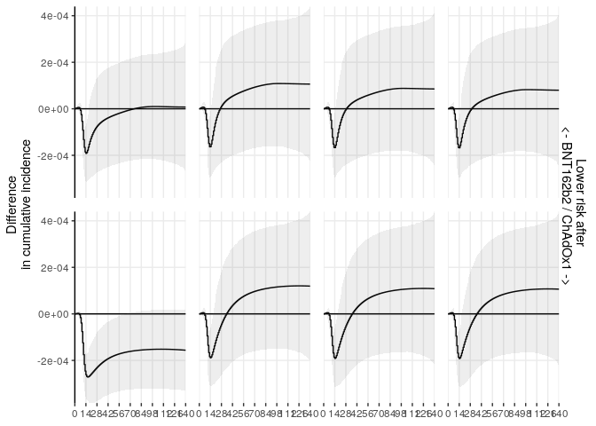